# Explore DNT NTP 2021 Chemicals to Retest

Amy Carpenter

5/2/2022

# 1 Purpose

Implement tcpl-like normalization To predict which chemicals seem to be having a response at the lowest conc tested And so should be repeated at lower conc’s

# 2 Functions

```r
# Level 6 plot function

plot_dose_response <- function(plotdat) {
  p <- ggplot(plotdat, aes(x = conc, y = resp)) +
    geom_point(pch = 1, size = 2, stroke = 2) +
    scale_x_log10()+
    geom_hline(aes(yintercept = coff_invitrodb), lty = 'dashed')+
    geom_hline(yintercept = 0)+
    ggtitle(paste0(unique(plotdat$aenm),'\n',unique(plotdat$treatment,'\ndashed line = invitrodb cutoff')))
  print(p)
}
```

# 3 Load data

```r
load(file.path('DNT_NTP2021','check_for_chem_to_rescreen','DNT_NTP2021_preliminary_in_house_normalized_values_2022-05-02.RData'))
cat(description)
```

```
## An mc3-like table containing resp values along with current invitrodb cutoffs.
## Created from DNT_NTP2021_preliminary_longfile.RData.
## Created with apply_in_house_tcpl-like_processing_2022-05-02.R
```

# 4 Compare bmads in invitrodb vs this data which will be added

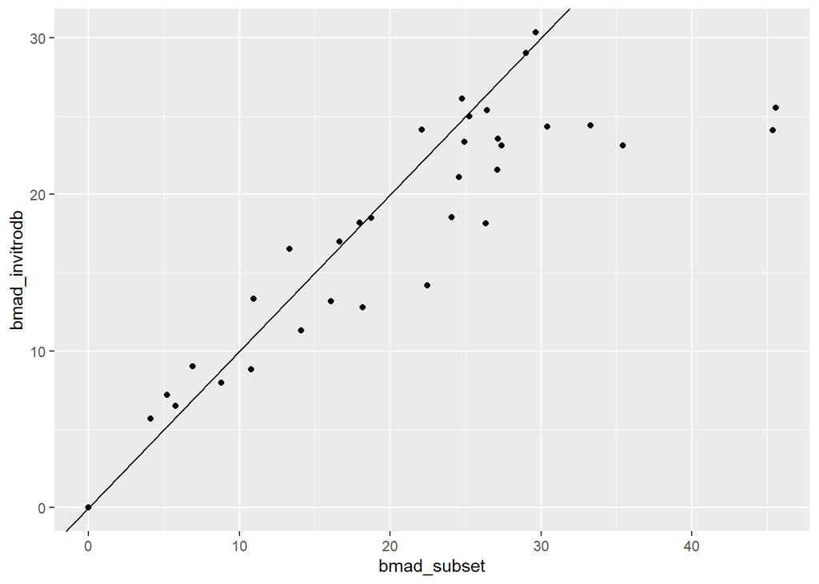

```r
comp.bmads <- dat2[, unique(.SD), .SDcols = c('bmad_subset','bmad_invitrodb')]
ggplot(comp.bmads, aes(x = bmad_subset, y = bmad_invitrodb)) +
  geom_point()+
  geom_abline(slope = 1, intercept = 0)
```

Bmads are fairly similar. only significant deviation is where bmad.subset is a bit larger. So some coffs will possibly be a bit larger after the addition of this data. Just something to keep in mind.

# 5 Explore results

```r
dat2[cndx %in% c(1,2), summary(med_resp_by_cndx)]
```

```
##      Min.   1st Qu.    Median      Mean   3rd Qu.      Max.      NA's
## -928.0808   -4.6325    0.0000    0.1722    5.1967  928.0808       540
```

```r
dat2[cndx %in% c(1,2), summary(med_resp_vs_coff)]
```

```
##    Min. 1st Qu.  Median    Mean 3rd Qu.    Max.    NA's
##    -Inf  -0.125   0.000     NaN   0.136     Inf    3270
```

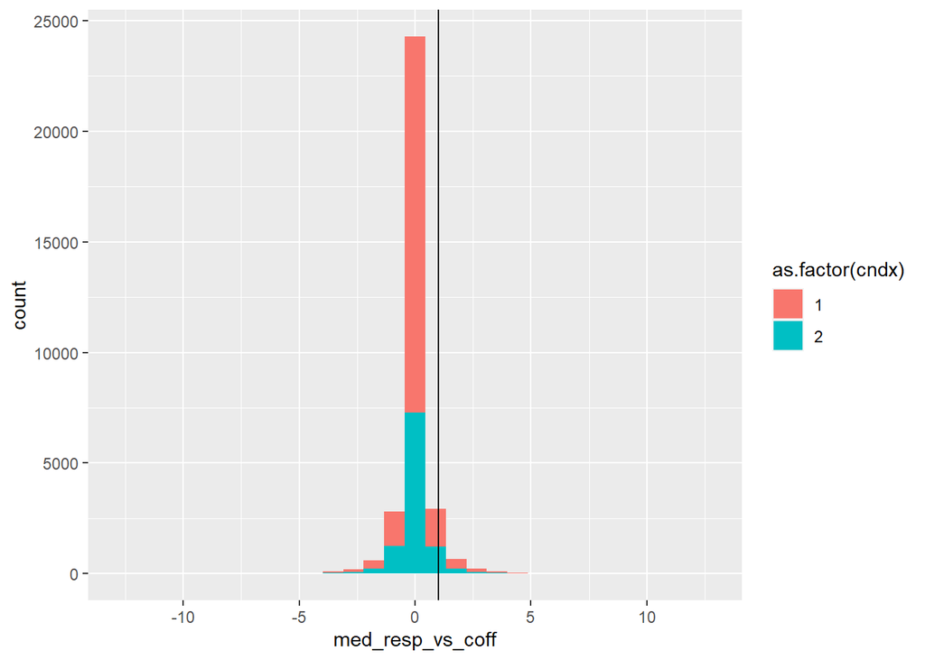

```r
ggplot(dat2[!grepl('DIV12',aenm) & cndx %in% c(1,2)], aes(x = med_resp_vs_coff))+
  geom_histogram(aes(fill = as.factor(cndx)))+
  geom_vline(xintercept = 1)
```

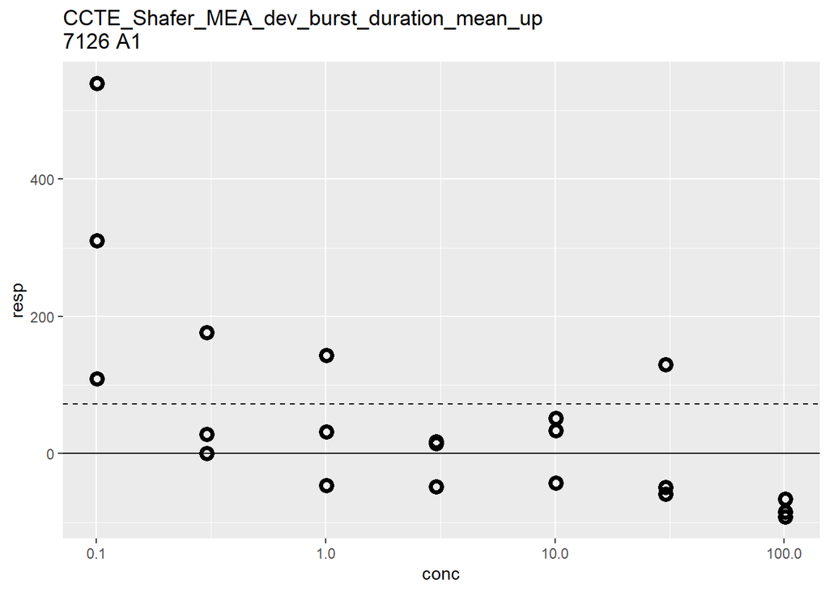

```r
# Let's visualize some of these cases to confirm
trt.aenms <- dat2[!grepl('DIV12',aenm) & cndx %in% c(1,2) & med_resp_vs_coff > 1.1, unique(.SD), .SDcols = c('treatment','aenm')]
setkey(trt.aenms, treatment, aenm)
setkey(dat2, treatment, aenm)


plot_dose_response(dat2[.(trt.aenms[1])])
```

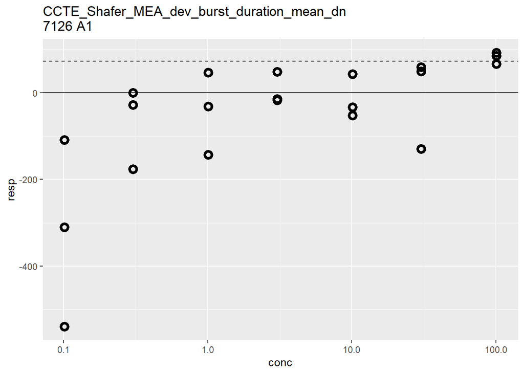

```r
# this looks like jsut a dn response...
plot_dose_response(dat2[treatment == '7126 A1' & aenm == 'CCTE_Shafer_MEA_dev_burst_duration_mean_dn'])
```

```r
# oofta... was the bval just really low here?
dat2[aenm == 'CCTE_Shafer_MEA_dev_burst_duration_mean_dn', summary(bval)]
```

```
##    Min. 1st Qu.  Median    Mean 3rd Qu.    Max.
##   1.160   4.387   6.243   7.104   8.819  21.012
```

```r
# 1.160   4.406   6.252   7.134   8.819  21.012
dat2[aenm == 'CCTE_Shafer_MEA_dev_burst_duration_mean_dn' & treatment == '7126 A1', unique(bval)]
```

```
## [1]  6.934964 10.568015  5.339662
```

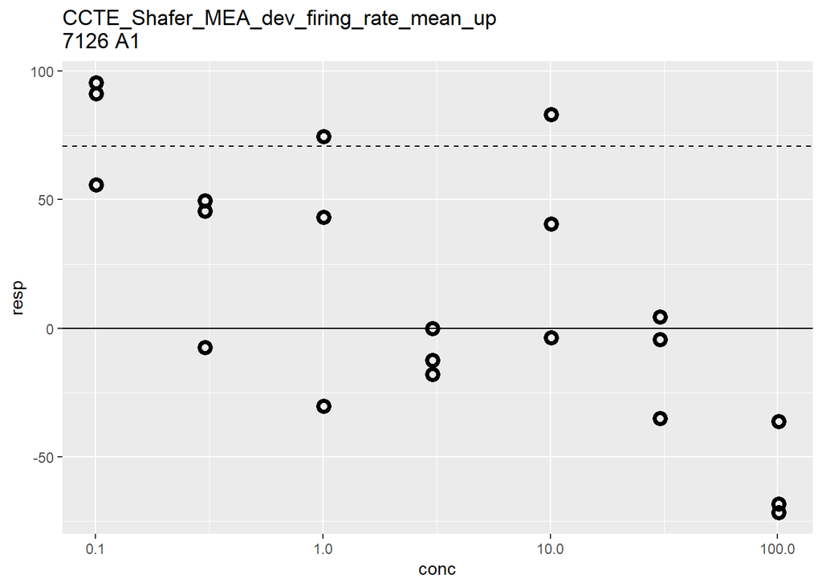

```r
# 6.934964 10.568015  5.339662
# Nope, most are quite normal!!

plot_dose_response(dat2[.(trt.aenms[2])])
```

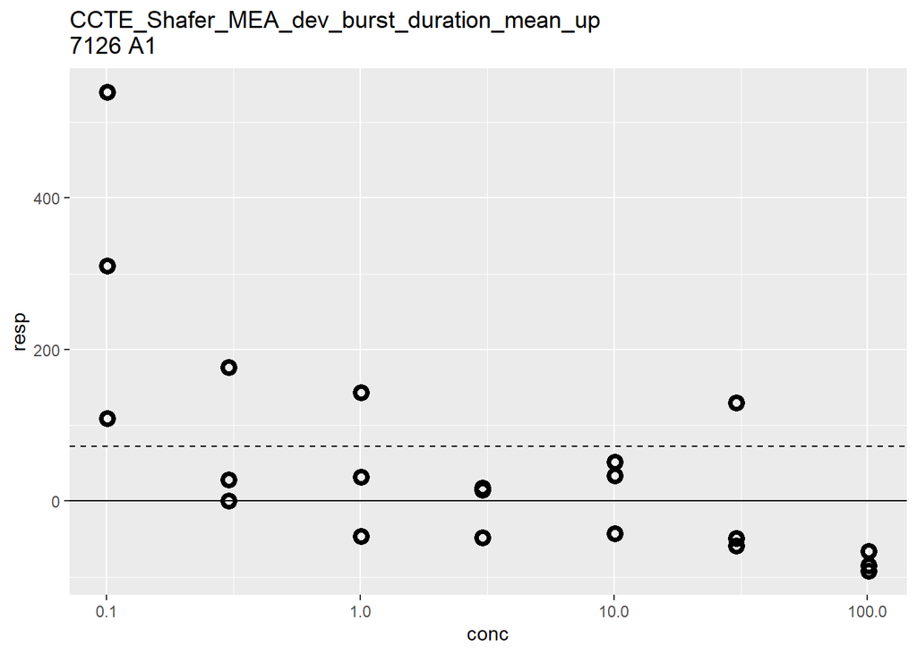

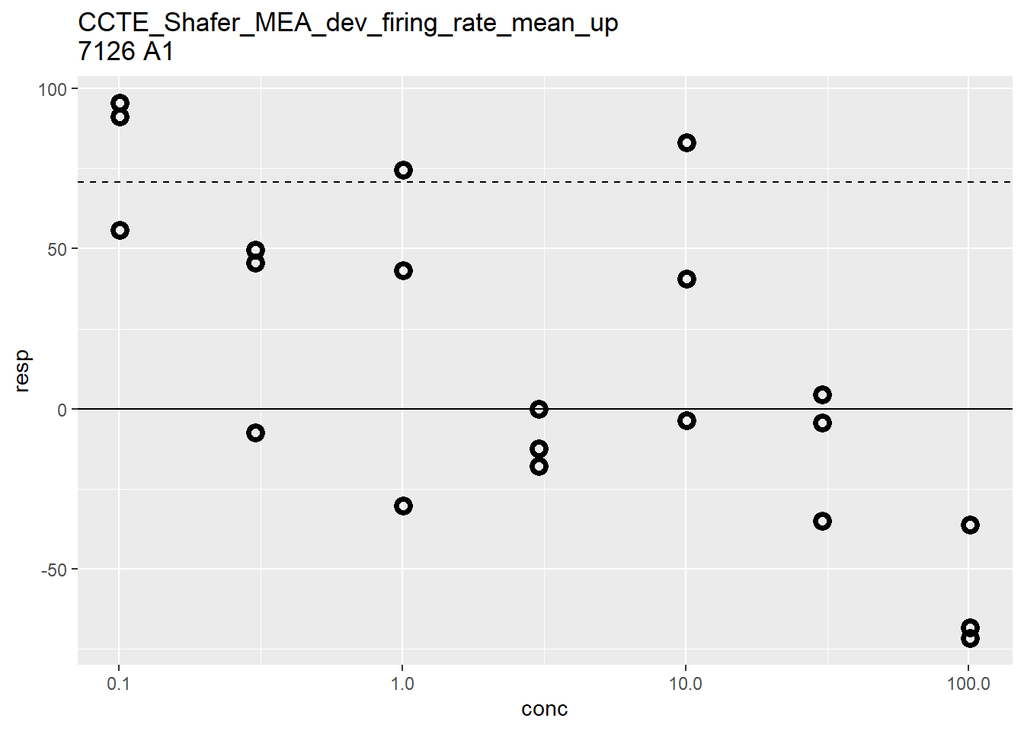

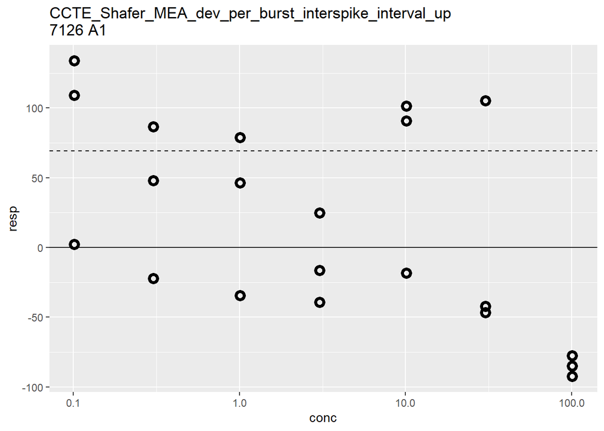

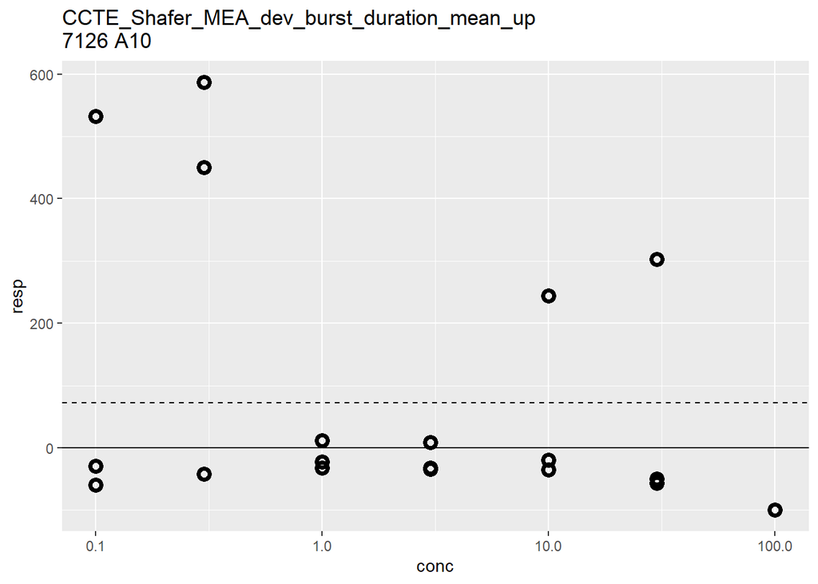

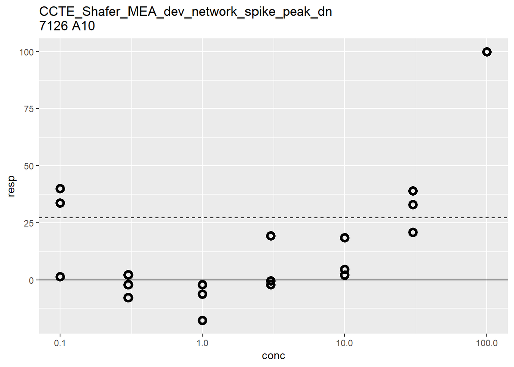

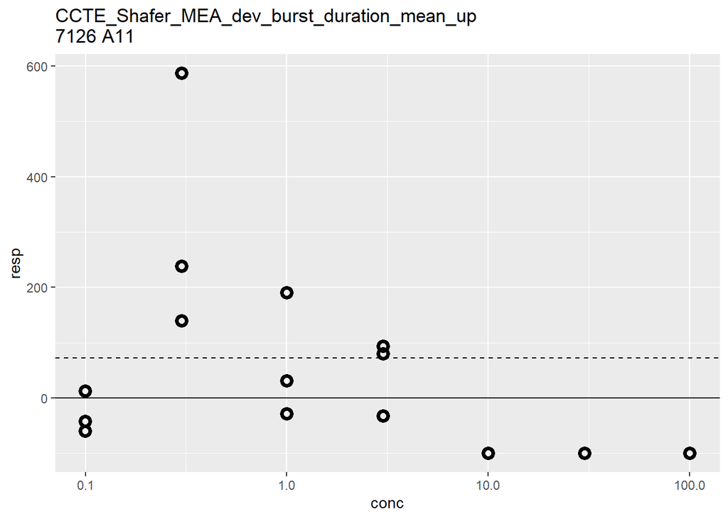

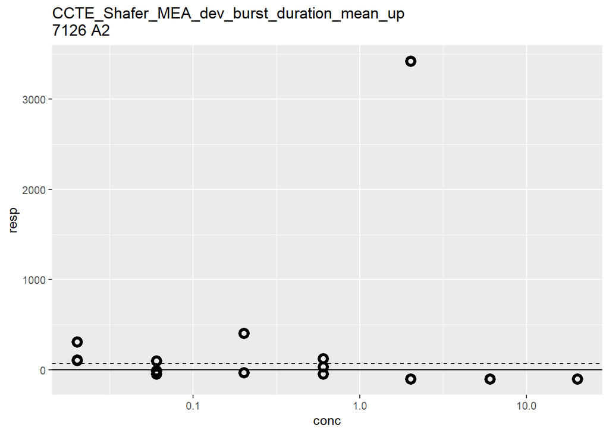

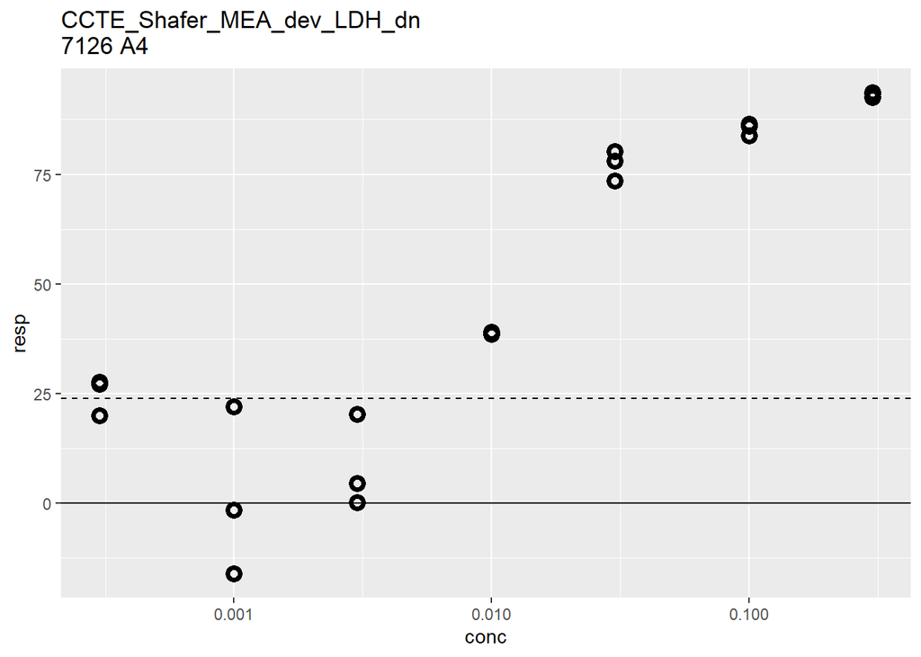

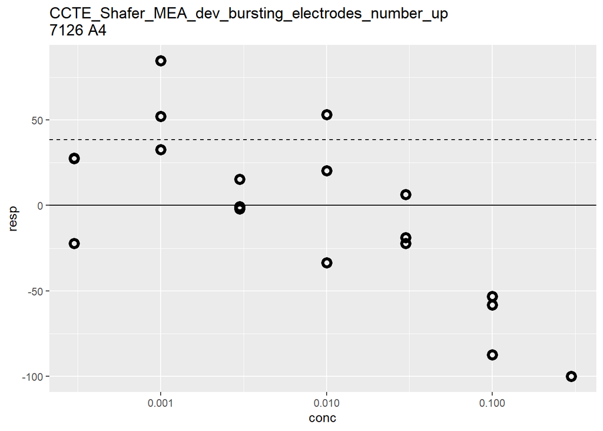

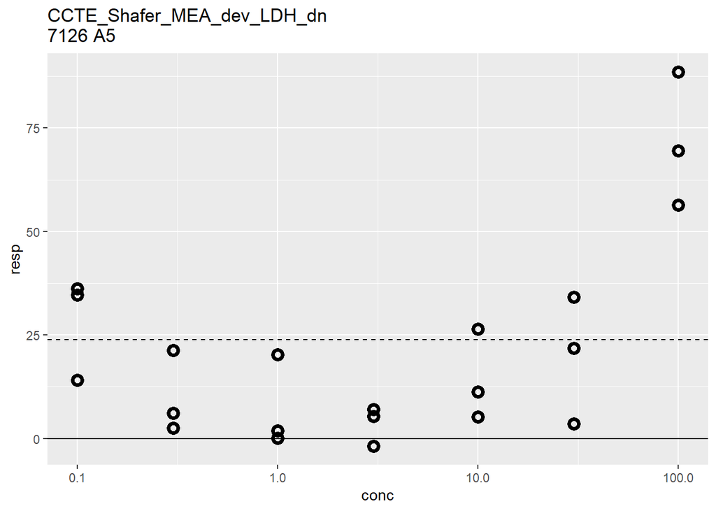

```r
# similar

for (i in 1:10) {
  plot_dose_response(dat2[.(trt.aenms[i])])

}
```

Thoughts:

- I want to weed out cases that are just noisy, or have a weird blip at low conc’s, then bounce back up
- Also, I almost don’t care about the up, these seem to introduce more issues. I think I"m okay to ignore those cases

# 6 Use minimum consecutive cndx above coff as a threshold

## 6.1 See distribution of min consecutive cndx above coff

```r
# Find the lowest conc at which it and all following conc's are above the coff
dat2[, max_cndx_below_coff := max(cndx[med_resp_vs_coff < 1], na.rm  = T), by = .(treatment, aenm)]
dat2[any_wllq1 == 1 & (is.na(max_cndx_below_coff) | is.infinite(max_cndx_below_coff)), max_cndx_below_coff := 0] # if no med resp's are below the coff
dat2[, max_cndx := max(cndx, na.rm = T), by = .(treatment, aenm)]
dat2[, min_consecutive_cndx_above_coff := pmin(max_cndx_below_coff+1, max_cndx), by = .(treatment, aenm)]
dat2[, summary(min_consecutive_cndx_above_coff)]
```

```
##    Min. 1st Qu.  Median    Mean 3rd Qu.    Max.
##   1.000   5.000   7.000   5.537   7.000   7.000
```

```r
# Min. 1st Qu.  Median    Mean 3rd Qu.    Max.    NA's
# 1.000   5.000   7.000   5.527   7.000   7.000    1302
dat2[is.na(min_consecutive_cndx_above_coff), .N, by = .(any_wllq1)]
```

| any_wllq1 | N |
| --- | --- |

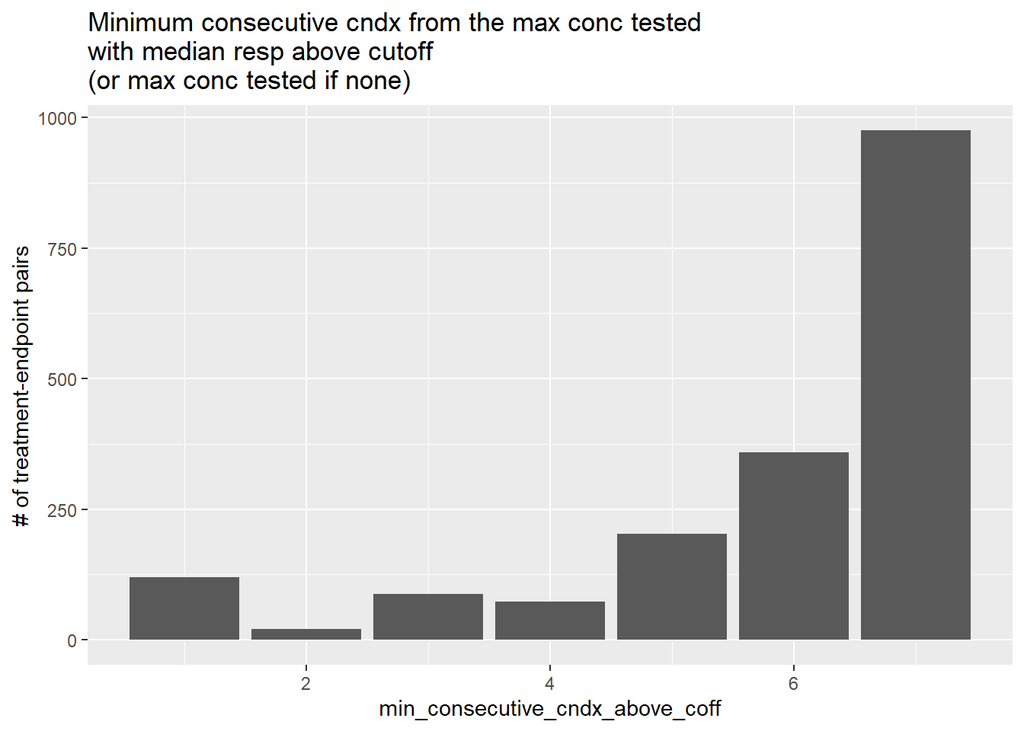

```r
# any_wllq1    N
# 1:         0 1302
# cool, all the treatment-aenm's with NA values just don't have any useable points

# View distribution
plotdat <- dat2[!grepl('DIV12',aenm) & !grepl('_up',aenm), unique(.SD), .SDcols = c('treatment','aenm','min_consecutive_cndx_above_coff')]
ggplot(plotdat, aes(x = min_consecutive_cndx_above_coff)) +
  geom_bar()+
  ylab('# of treatment-endpoint pairs')+
  ggtitle('Minimum consecutive cndx from the max conc tested\nwith median resp above cutoff\n(or max conc tested if none)')
```

## 6.2 Okay, so what’s going to be the min requirement for number of cndx below coff?

### 6.2.1 Is 3 cndx below coff sufficient?

```r
check.rows <- dat2[!grepl('DIV12',aenm) & !grepl('_up',aenm) & min_consecutive_cndx_above_coff == 4, unique(.SD), .SDcols = c('treatment','aenm')]
setkey(dat2, treatment, aenm)
nrow(check.rows) # 98
```

```
## [1] 73
```

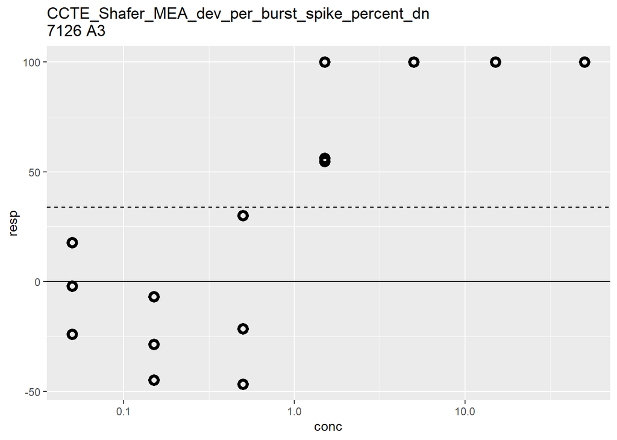

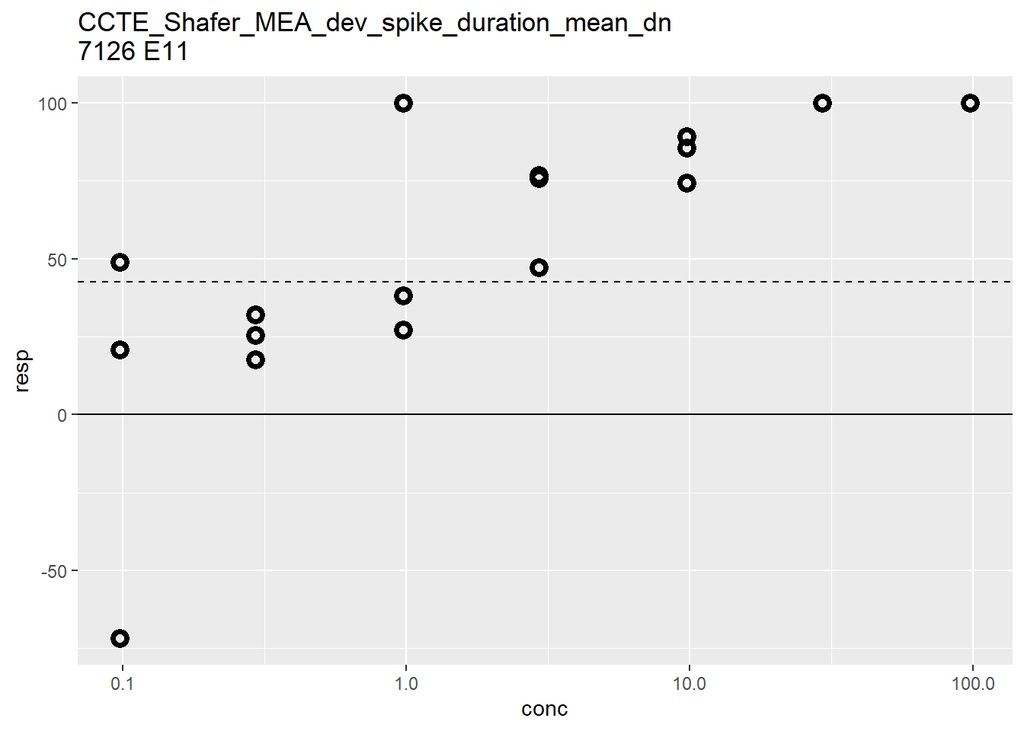

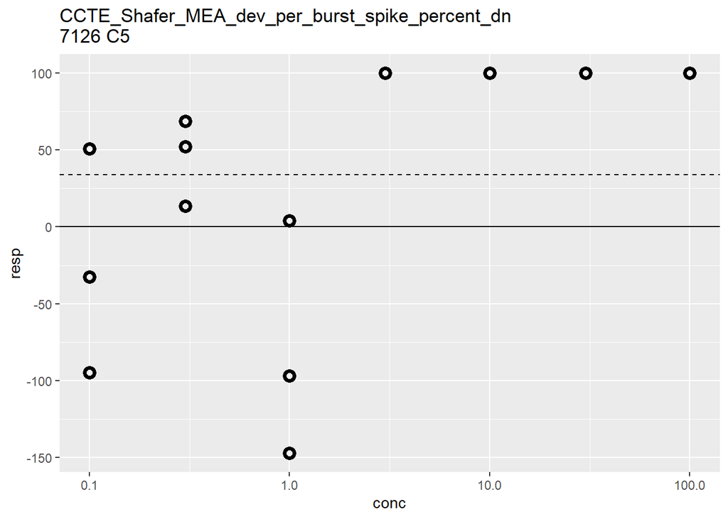

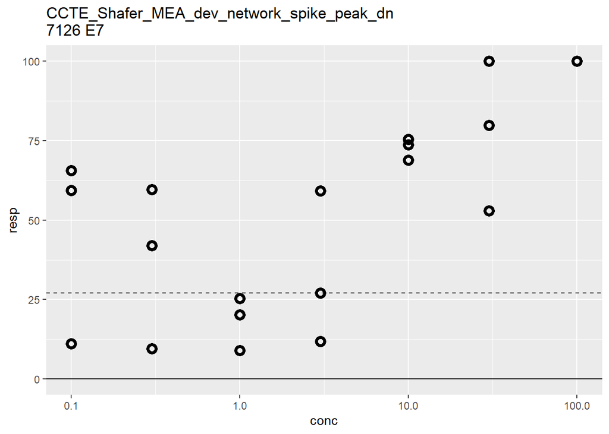

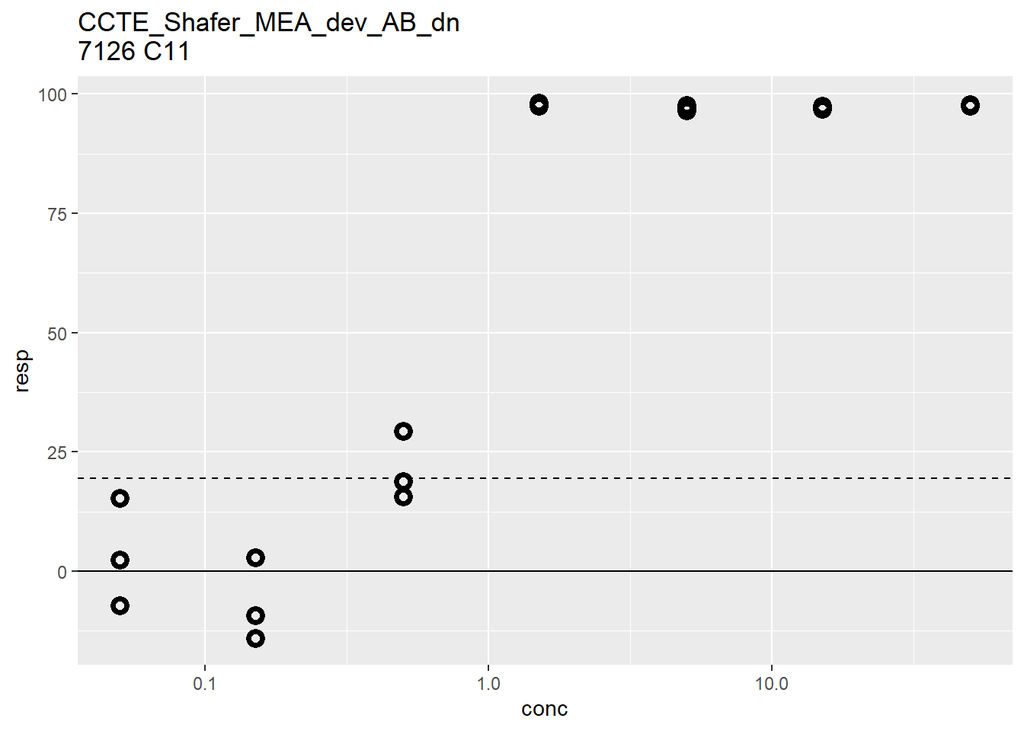

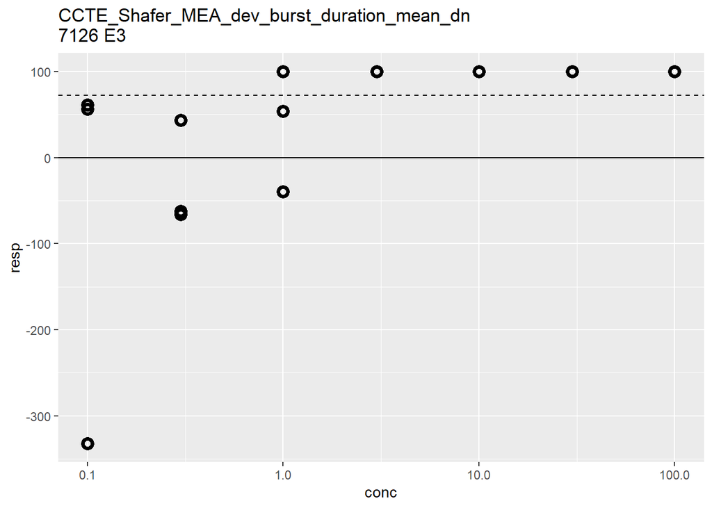

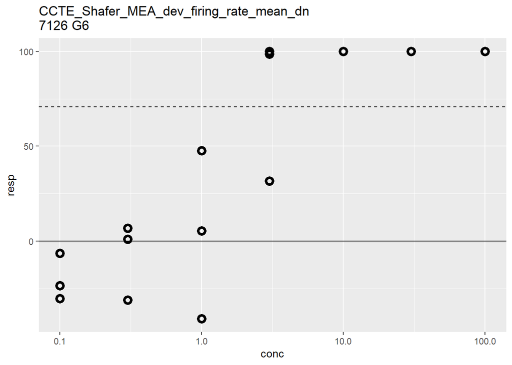

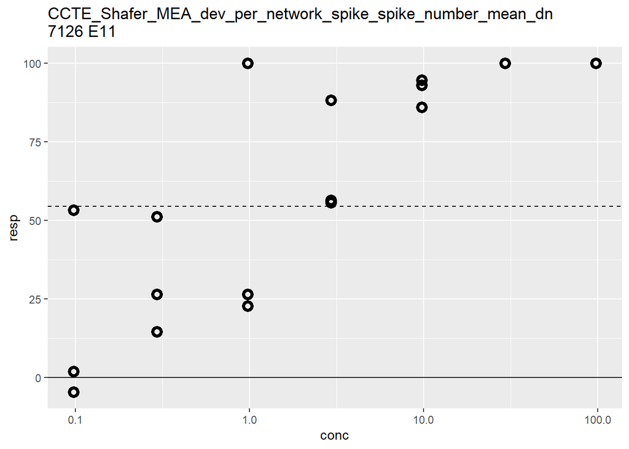

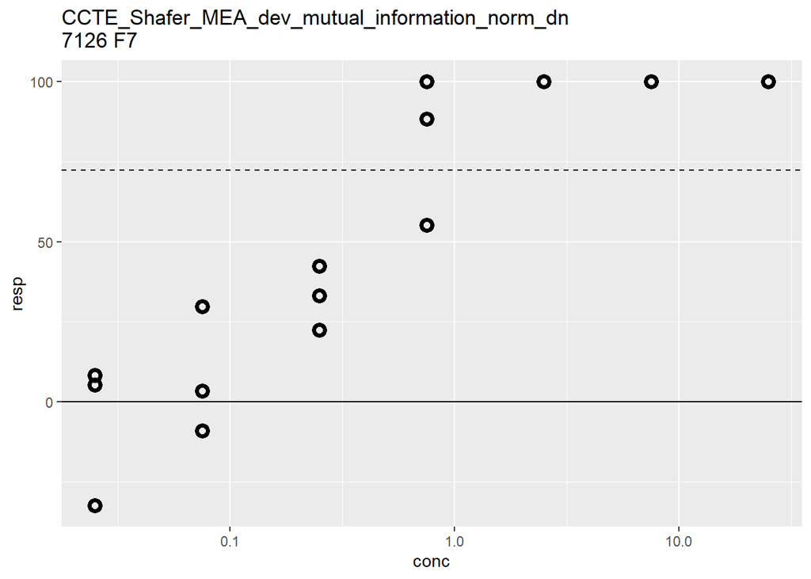

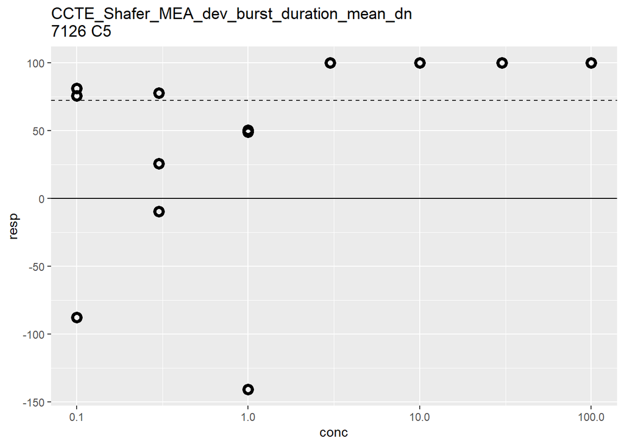

```r
for (i in sample(nrow(check.rows), size = 10)) {
  plot_dose_response(dat2[.(check.rows[i])])
}
```

Yes, for sure

### 6.2.2 Is 2 cndx below coff sufficient?

```r
check.rows <- dat2[!grepl('DIV12',aenm) & !grepl('_up',aenm) & min_consecutive_cndx_above_coff == 3, unique(.SD), .SDcols = c('treatment','aenm')]
setkey(dat2, treatment, aenm)
nrow(check.rows) # 91
```

```
## [1] 88
```